# Jogos de Xadrez

## O dataset

Dados sobre mais de 20,000 jogos de xadrez jogados no Lichess, com movimentos, quem ganhou, o rating, abertura e outros.

```r
library(tidyverse)
chess_data <- read.csv('chess_games1.csv')
chess_data
```

| game_id | rated | turns | victory_status | winner | time_increment | white_id | white_rating | black_id | black_rating | moves | opening_moves | opening_name |
| --- | --- | --- | --- | --- | --- | --- | --- | --- | --- | --- | --- | --- |
| 1 | FALSE | 13 | Out of Time | White | 15+2 | bourgris | 1500 | a-00 | 1191 | d4 d5 c4 c6 cxd5 e6 dxe6 fxe6 Nf3 Bb4+ Nc3 Ba5 Bf4 | 5 | Slav Defense |
| 2 | TRUE | 16 | Resign | Black | 5+10 | a-00 | 1322 | skinnerua | 1261 | d4 Nc6 e4 e5 f4 f6 dxe5 fxe5 fxe5 Nxe5 Qd4 Nc6 Qe5+ Nxe5 c4 Bb4+ | 4 | Nimzowitsch Defense |
| 3 | TRUE | 61 | Mate | White | 5+10 | ischia | 1496 | a-00 | 1500 | e4 e5 d3 d6 Be3 c6 Be2 b5 Nd2 a5 a4 c5 axb5 Nc6 bxc6 Ra6 Nc4 a4 c3 a3 Nxa3 Rxa3 Rxa3 c4 dxc4 d5 cxd5 Qxd5 exd5 Be6 Ra8+ Ke7 Bc5+ Kf6 Bxf8 Kg6 Bxg7 Kxg7 dxe6 Kh6 exf7 Nf6 Rxh8 Nh5 Bxh5 Kg5 Rxh7 Kf5 Qf3… | 3 | King's Pawn Game |
| 4 | TRUE | 61 | Mate | White | 20+0 | daniamurashov | 1439 | adivanov2009 | 1454 | d4 d5 Nf3 Bf5 Nc3 Nf6 Bf4 Ng4 e3 Nc6 Be2 Qd7 O-O O-O-O Nb5 Nb4 Rc1 Nxa2 Ra1 Nb4 Nxa7+ Kb8 Nb5 Bxc2 Bxc7+ Kc8 Qd2 Qc6 Na7+ Kd7 Nxc6 bxc6 Bxd8 Kxd8 Qxb4 e5 Qb8+ Ke7 dxe5 Be4 Ra7+ Ke6 Qe8+ Kf5 Qxf7+ Nf6 … | 3 | Queen's Pawn Game |
| 5 | TRUE | 95 | Mate | White | 30+3 | nik221107 | 1523 | adivanov2009 | 1469 | e4 e5 Nf3 d6 d4 Nc6 d5 Nb4 a3 Na6 Nc3 Be7 b4 Nf6 Bg5 O-O b5 Nc5 Bxf6 Bxf6 Bd3 Qd7 O-O Nxd3 Qxd3 c6 a4 cxd5 Nxd5 Qe6 Nc7 Qg4 Nxa8 Bd7 Nc7 Rc8 Nd5 Qg6 Nxf6+ Qxf6 Rfd1 Re8 Qxd6 Bg4 Qxf6 gxf6 Rd3 Bxf3 Rxf… | 5 | Philidor Defense |
| 6 | FALSE | 5 | Draw | Draw | 10+0 | trelynn17 | 1250 | franklin14532 | 1002 | e4 c5 Nf3 Qa5 a3 | 4 | Sicilian Defense |
| 7 | TRUE | 33 | Resign | White | 10+0 | capa_jr | 1520 | daniel_likes_chess | 1423 | d4 d5 e4 dxe4 Nc3 Nf6 f3 exf3 Nxf3 Nc6 Bb5 a6 Bd3 Bg4 O-O Nxd4 Be2 Nxe2+ Qxe2 Bxf3 Qxf3 Qd4+ Be3 Qg4 Qxb7 Rd8 Qc6+ Nd7 Nd5 e6 Nxc7+ Ke7 Bd2 | 10 | Blackmar-Diemer Gambit |
| 8 | FALSE | 9 | Resign | Black | 15+30 | daniel_likes_chess | 1413 | soultego | 2108 | e4 Nc6 d4 e5 d5 Nce7 c3 Ng6 b4 | 5 | Nimzowitsch Defense |
| 9 | TRUE | 66 | Resign | Black | 15+0 | ehabfanri | 1439 | daniel_likes_chess | 1392 | e4 e5 Bc4 Nc6 Nf3 Nd4 d3 Nxf3+ Qxf3 Nf6 h3 Bc5 a3 O-O Be3 Bxe3 Qxe3 Re8 Qf3 c6 Nc3 b5 Bb3 Qa5 O-O Bb7 Ne2 c5 Rfd1 d6 c4 bxc4 dxc4 Rac8 Rd5 Bxd5 exd5 Qb6 Nc1 e4 Qf4 Nh5 Qg4 Nf6 Qf4 Qa5 Bc2 Qe1+ Kh2 Nh5… | 6 | Italian Game |
| 10 | TRUE | 119 | Mate | White | 10+0 | daniel_likes_chess | 1381 | mirco25 | 1209 | e4 d5 exd5 Qxd5 Nc3 Qe5+ Be2 Na6 d4 Qf5 Bxa6 bxa6 Nf3 Qe6+ Be3 Bb7 Ng5 Qc4 Qh5 Bxg2 Qxf7+ Qxf7 Nxf7 Kxf7 Rg1 Bf3 Rg3 Bh5 Rh3 g6 Ne4 Nf6 Nc5 e6 Nxa6 Rc8 Bf4 Bg4 Rg3 c6 Nb4 Bxb4+ c3 Ba5 b4 Bc7 Bxc7 Rxc7… | 4 | Scandinavian Defense |

[output cut: 990 more lines]

Carregando o dataset.

## “Limpeza” de Dados

```r
a <- select(chess_data, victory_status, turns, winner, white_rating, black_rating) %>%
  mutate(diferenca_rating = white_rating - black_rating) %>%
  mutate(mod_diferenca_rating = abs(white_rating - black_rating)) %>%
  mutate(dif_result_rating = ifelse((winner=="White") & (diferenca_rating > 0),"maior_branco_ganhou",
                             ifelse((winner=="Black") & (diferenca_rating < 0),"maior_preto_ganhou",
                             ifelse((winner=="Black") & (diferenca_rating > 0),"menor_preto_ganhou",
                             ifelse((winner=="White") & (diferenca_rating < 0),"menor_branco_ganhou",
                             ifelse((winner=="Draw"), "empate",
                             ifelse((diferenca_rating == 0), "igualado","N/A"))))))) %>%
  mutate(result_maior = ifelse((winner=="White") & (diferenca_rating > 0),"maior_ganhou",
                        ifelse((winner=="Black") & (diferenca_rating < 0),"maior_ganhou",
                        ifelse((winner=="Black") & (diferenca_rating > 0),"maior_perdeu",
                        ifelse((winner=="White") & (diferenca_rating < 0),"maior_perdeu",
                        ifelse((winner=="Draw"), "empate",
                        ifelse((diferenca_rating == 0), "igualado","N/A"))))))) %>%
  mutate(result_dif = ifelse(((result_maior=="maior_ganhou")|(result_maior =="igualado")) & (mod_diferenca_rating < 100),"100",
                      ifelse((result_maior=="maior_ganhou") & (mod_diferenca_rating < 200),"200",
                      ifelse((result_maior=="maior_ganhou") & (mod_diferenca_rating < 300),"300",
                      ifelse((result_maior=="maior_ganhou") & (mod_diferenca_rating < 400),"400",
                      ifelse((result_maior=="maior_ganhou") & (mod_diferenca_rating < 500),"500",
                      ifelse((result_maior=="maior_ganhou") & (mod_diferenca_rating > 500),">500",
                      ifelse(((result_maior=="maior_perdeu")|(result_maior=="empate")|(result_maior=="igualado"))& (mod_diferenca_rating < 100),"-100",
                      ifelse(((result_maior=="maior_perdeu")|(result_maior=="empate"))& (mod_diferenca_rating < 200),"-200",
                      ifelse(((result_maior=="maior_perdeu")|(result_maior=="empate"))& (mod_diferenca_rating < 300),"-300",
                      ifelse(((result_maior=="maior_perdeu")|(result_maior=="empate"))& (mod_diferenca_rating < 400),"-400",
                      ifelse(((result_maior=="maior_perdeu")|(result_maior=="empate"))& (mod_diferenca_rating < 500),"-500",
                      ifelse(((result_maior=="maior_perdeu")|(result_maior=="empate"))& (mod_diferenca_rating > 500),"<-500",0))))))))))))) %>%
  mutate(part_dif = ifelse((mod_diferenca_rating < 100),"dif_100",
                    ifelse((mod_diferenca_rating < 200),"dif_200",
                    ifelse((mod_diferenca_rating < 300),"dif_300",
                    ifelse((mod_diferenca_rating < 400),"dif_400",
                    ifelse((mod_diferenca_rating < 500),"dif_500",
                    ifelse((mod_diferenca_rating > 500),"dif_500+",
                    ifelse((mod_diferenca_rating == 0), "igualado","N/A")))))))) %>%
 mutate(result_dif = factor(result_dif, levels=c("<-500", "-500", "-400", "-300", "-200", "-100",
                                                 "100", "200", "300", "400", "500", ">500")))
a
```

| victory_status | turns | winner | white_rating | black_rating | diferenca_rating | mod_diferenca_rating | dif_result_rating | result_maior | result_dif | part_dif |
| --- | --- | --- | --- | --- | --- | --- | --- | --- | --- | --- |
| Out of Time | 13 | White | 1500 | 1191 | 309 | 309 | maior_branco_ganhou | maior_ganhou | 400 | dif_400 |
| Resign | 16 | Black | 1322 | 1261 | 61 | 61 | menor_preto_ganhou | maior_perdeu | -100 | dif_100 |
| Mate | 61 | White | 1496 | 1500 | -4 | 4 | menor_branco_ganhou | maior_perdeu | -100 | dif_100 |
| Mate | 61 | White | 1439 | 1454 | -15 | 15 | menor_branco_ganhou | maior_perdeu | -100 | dif_100 |
| Mate | 95 | White | 1523 | 1469 | 54 | 54 | maior_branco_ganhou | maior_ganhou | 100 | dif_100 |
| Draw | 5 | Draw | 1250 | 1002 | 248 | 248 | empate | empate | -300 | dif_300 |
| Resign | 33 | White | 1520 | 1423 | 97 | 97 | maior_branco_ganhou | maior_ganhou | 100 | dif_100 |
| Resign | 9 | Black | 1413 | 2108 | -695 | 695 | maior_preto_ganhou | maior_ganhou | >500 | dif_500+ |
| Resign | 66 | Black | 1439 | 1392 | 47 | 47 | menor_preto_ganhou | maior_perdeu | -100 | dif_100 |
| Mate | 119 | White | 1381 | 1209 | 172 | 172 | maior_branco_ganhou | maior_ganhou | 200 | dif_200 |

[output cut: 990 more lines]

Aqui eu criei  
- Uma coluna com a diferença absoluta e normal de rating entre os jogadores.  
- Uma coluna que categoriza as partidas de acordo com quem ganhou e se esse que ganhou tinha maior rating.  
- Uma coluna que categoriza as partidas de acordo com a pessoa de maior rating, qual era essa diferença e se ele perdeu.  
- Uma coluna que diz se a com quanto de diferença de rating a pessoa de maior rating ganhou ou perdeu. - A ultima coluna é para categorizar jogos pela diferença absoluta de rating.

## Tentativas

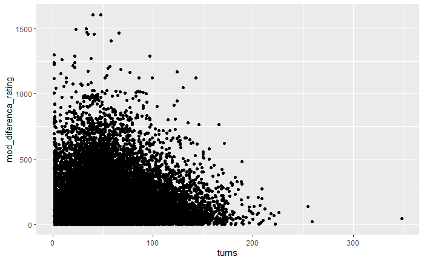

```r
ggplot(a, aes(x = turns, y = mod_diferenca_rating)) +
  geom_point()
```

Uma tentativa de observar se quanto maior a diferença de rating, menor seria o número de turnos.

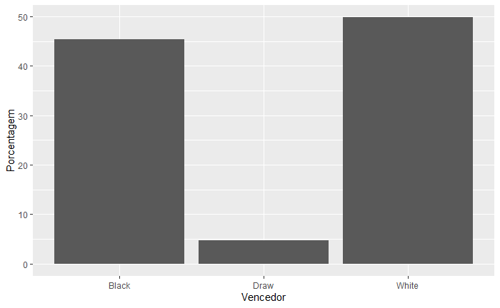

```r
ggplot(a, aes(winner))+
  geom_bar(position = "dodge", mapping = aes(y = ..prop..*100,
                                             group = 1)) +
  labs(x = "Vencedor", y = "Porcentagem") +
  theme(legend.position = "top")
```

Quem ganhou mais?

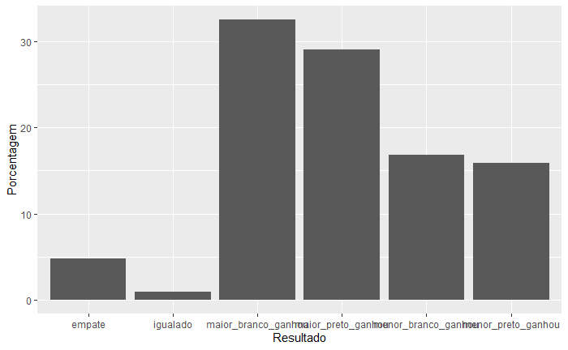

```r
ggplot(a, aes(dif_result_rating))+
  geom_bar(position = "dodge", mapping = aes(y = ..prop..*100,
                                             group = 1)) +
  labs(x = "Resultado", y = "Porcentagem") +
  theme(legend.position = "top")
```

O resultado pelo jogador de maior rating, os de maior rating tem mais chance de ganhar com as Brancas.

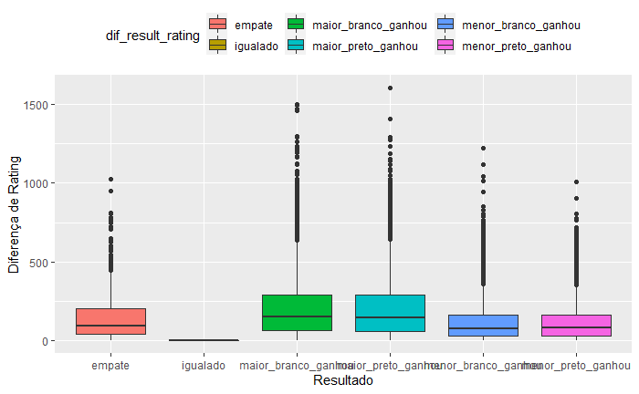

```r
ggplot(a, aes(dif_result_rating, mod_diferenca_rating, fill=dif_result_rating)) +
  geom_boxplot(position = "dodge", mapping = aes(y = mod_diferenca_rating)) +
  labs(x = "Resultado", y = "Diferença de Rating") +
  theme(legend.position = "top")
```

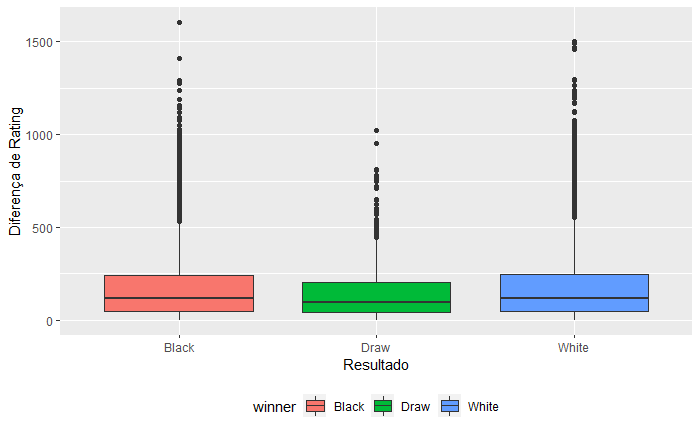

```r
ggplot(a, aes(winner, mod_diferenca_rating, fill=winner))+
  geom_boxplot(position = "dodge", mapping = aes(y = mod_diferenca_rating)) +
  labs(x = "Resultado", y = "Diferença de Rating") +
  theme(legend.position = "bottom")
```

Uma vizualização meio ruim, não destaca a diferença entre pretas e brancas.

## O gráfico

A ideia é que a chance do jogador pelo rating faz uma curva em “s”.

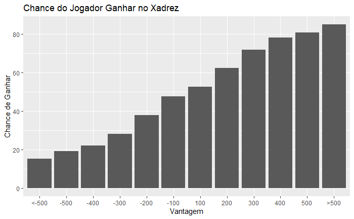

```r
lista=c("<-500", "-500", "-400", "-300", "-200", "-100",
"100", "200", "300", "400", "500", ">500")
b<- subset(a,result_dif %in% lista)
ggplot(b, aes(result_dif)) +
  geom_bar(position = "dodge", mapping = aes(y = ..prop..*100,
                                             group = part_dif)) +
  labs(x = "Vantagem", y = "Chance de Ganhar", title = "Chance do Jogador Ganhar no Xadrez") +
  theme_set(theme_bw()) +
  theme(legend.position = "top")
```

Eu calculei a “chance” dividindo os jogos ganhou com uma diferença pelo total de jogos com essa mesma diferença de rating.

Ainda falta adicionar a diferença entre pretas e brancas.

```r
d <- mutate(a, cor_result_dif = ifelse((dif_result_rating=="maior_branco_ganhou") & (part_dif=="dif_100"),"b100",
                      ifelse((dif_result_rating=="maior_branco_ganhou") & (part_dif=="dif_200"),"b200",
                      ifelse((dif_result_rating=="maior_branco_ganhou") & (part_dif=="dif_300"),"b300",
                      ifelse((dif_result_rating=="maior_branco_ganhou") & (part_dif=="dif_400"),"b400",
                      ifelse((dif_result_rating=="maior_branco_ganhou") & (part_dif=="dif_500"),"b500",
                      ifelse((dif_result_rating=="maior_branco_ganhou") & (part_dif=="dif_500+"),"b>500",
                      ifelse(((dif_result_rating=="menor_branco_ganhou")|(dif_result_rating=="empate"))& (part_dif=="dif_100"),"b-100",
                      ifelse(((dif_result_rating=="menor_branco_ganhou")|(dif_result_rating=="empate"))& (part_dif=="dif_200"),"b-200",
                      ifelse(((dif_result_rating=="menor_branco_ganhou")|(dif_result_rating=="empate"))& (part_dif=="dif_300"),"b-300",
                      ifelse(((dif_result_rating=="menor_branco_ganhou")|(dif_result_rating=="empate"))& (part_dif=="dif_400"),"b-400",
                      ifelse(((dif_result_rating=="menor_branco_ganhou")|(dif_result_rating=="empate"))& (part_dif=="dif_500"),"b-500",
                      ifelse(((dif_result_rating=="menor_branco_ganhou")|(dif_result_rating=="empate"))& (part_dif=="dif_500+"),"b<-500",
                      ifelse((dif_result_rating=="maior_preto_ganhou")& (part_dif=="dif_100"),"p100",
                      ifelse((dif_result_rating=="maior_preto_ganhou")& (part_dif=="dif_200"),"p200",
                      ifelse((dif_result_rating=="maior_preto_ganhou")& (part_dif=="dif_300"),"p300",
                      ifelse((dif_result_rating=="maior_preto_ganhou")& (part_dif=="dif_400"),"p400",
                      ifelse((dif_result_rating=="maior_preto_ganhou")& (part_dif=="dif_500"),"p500",
                      ifelse((dif_result_rating=="maior_preto_ganhou")& (part_dif=="dif_500+"),"p>500",
                      ifelse(((dif_result_rating=="menor_preto_ganhou")|(dif_result_rating=="empate"))& (part_dif=="dif_100"),"p-100",
                      ifelse(((dif_result_rating=="menor_preto_ganhou")|(dif_result_rating=="empate"))& (part_dif=="dif_200"),"p-200",
                      ifelse(((dif_result_rating=="menor_preto_ganhou")|(dif_result_rating=="empate"))& (part_dif=="dif_300"),"p-300",
                      ifelse(((dif_result_rating=="menor_preto_ganhou")|(dif_result_rating=="empate"))& (part_dif=="dif_400"),"p-400",
                      ifelse(((dif_result_rating=="menor_preto_ganhou")|(dif_result_rating=="empate"))& (part_dif=="dif_500"),"p-500",
                      ifelse(((dif_result_rating=="menor_preto_ganhou")|(dif_result_rating=="empate"))& (part_dif=="dif_500+"),"p<-500",0 ))))))))))))))))))))))))) %>%
     mutate(cor_result_dif = factor(cor_result_dif, levels=c("b<-500","p<-500", "b-500","p-500", "b-400","p-400", "b-300","p-300", "b-200","p-200", "b-100","p-100","b100","p100", "b200","p200", "b300","p300", "b400","p400", "b500","p500", "b>500","p>500"))) %>%
     mutate(relacao = ifelse(((cor_result_dif=="b100")|(cor_result_dif=="p-100")),"b>p100",
                      ifelse(((cor_result_dif=="b200")|(cor_result_dif=="p-200")),"b>p200",
                      ifelse(((cor_result_dif=="b300")|(cor_result_dif=="p-300")),"b>p300",
                      ifelse(((cor_result_dif=="b400")|(cor_result_dif=="p-400")),"b>p400",
                      ifelse(((cor_result_dif=="b500")|(cor_result_dif=="p-500")),"b>p500",
                      ifelse(((cor_result_dif=="b>500")|(cor_result_dif=="p<-500")),"b>p500+",
                      ifelse(((cor_result_dif=="p100")|(cor_result_dif=="b-100")),"p>b100",
                      ifelse(((cor_result_dif=="p200")|(cor_result_dif=="b-200")),"p>b200",
                      ifelse(((cor_result_dif=="p300")|(cor_result_dif=="b-300")),"p>b300",
                      ifelse(((cor_result_dif=="p400")|(cor_result_dif=="b-400")),"p>b400",
                      ifelse(((cor_result_dif=="p500")|(cor_result_dif=="b-500")),"p>b500",
                      ifelse(((cor_result_dif=="p>500")|(cor_result_dif=="b<-500")),"p>b500+",0)))))))))))))
d
```

| victory_status | turns | winner | white_rating | black_rating | diferenca_rating | mod_diferenca_rating | dif_result_rating | result_maior | result_dif | part_dif | cor_result_dif | relacao |
| --- | --- | --- | --- | --- | --- | --- | --- | --- | --- | --- | --- | --- |
| Out of Time | 13 | White | 1500 | 1191 | 309 | 309 | maior_branco_ganhou | maior_ganhou | 400 | dif_400 | b400 | b>p400 |
| Resign | 16 | Black | 1322 | 1261 | 61 | 61 | menor_preto_ganhou | maior_perdeu | -100 | dif_100 | p-100 | b>p100 |
| Mate | 61 | White | 1496 | 1500 | -4 | 4 | menor_branco_ganhou | maior_perdeu | -100 | dif_100 | b-100 | p>b100 |
| Mate | 61 | White | 1439 | 1454 | -15 | 15 | menor_branco_ganhou | maior_perdeu | -100 | dif_100 | b-100 | p>b100 |
| Mate | 95 | White | 1523 | 1469 | 54 | 54 | maior_branco_ganhou | maior_ganhou | 100 | dif_100 | b100 | b>p100 |
| Draw | 5 | Draw | 1250 | 1002 | 248 | 248 | empate | empate | -300 | dif_300 | b-300 | p>b300 |
| Resign | 33 | White | 1520 | 1423 | 97 | 97 | maior_branco_ganhou | maior_ganhou | 100 | dif_100 | b100 | b>p100 |
| Resign | 9 | Black | 1413 | 2108 | -695 | 695 | maior_preto_ganhou | maior_ganhou | >500 | dif_500+ | p>500 | p>b500+ |
| Resign | 66 | Black | 1439 | 1392 | 47 | 47 | menor_preto_ganhou | maior_perdeu | -100 | dif_100 | p-100 | b>p100 |
| Mate | 119 | White | 1381 | 1209 | 172 | 172 | maior_branco_ganhou | maior_ganhou | 200 | dif_200 | b200 | b>p200 |

[output cut: 990 more lines]

A ideia da Primeira coluna é dizer que ganhou e por qual vantagem ganhou, os empates são contados como vitoria do jogador de menor rating.  
A segunda coluna cria uma relação baseada nos jogos, por exemplo um jogo em que as pretas ganharam com 100 a mais de rating é contado na mesma categoria que um jogo em que as brancas perderam com 100 a menos de rating, era necessário para fazer a proporção no gráfico abaixo.

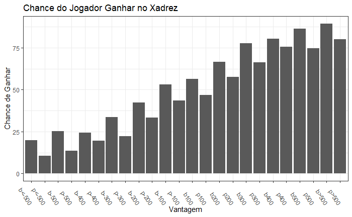

```r
list=c("b<-500","p<-500", "b-500","p-500", "b-400","p-400", "b-300","p-300", "b-200","p-200", "b-100","p-100","b100","p100", "b200","p200", "b300","p300", "b400","p400", "b500","p500", "b>500","p>500")
e<- subset(d,cor_result_dif %in% list)
ggplot(e, aes(cor_result_dif)) +
  geom_bar(position = "dodge", mapping = aes(y = ..prop..*100,
                                             group = relacao)) +
  labs(x = "Vantagem", y = "Chance de Ganhar", title = "Chance do Jogador Ganhar no Xadrez") +
  theme_set(theme_bw()) +
  theme(axis.text.x=element_text(angle=305,vjust=0.5,hjust=1)) +
  theme(legend.position = "top")
```

As colunas da esquerda são as brancas e as da direita são as pretas, esse gráfico mostra uma diferença bem significante na chance de ganhar das brancas e pretas.

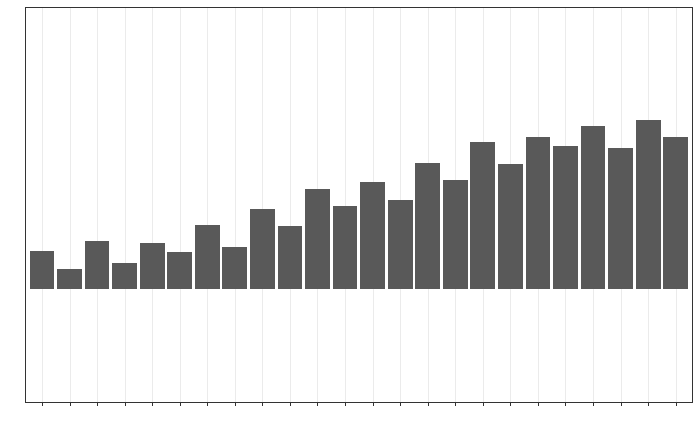

```r
list=c("b<-500","p<-500", "b-500","p-500", "b-400","p-400", "b-300","p-300", "b-200","p-200", "b-100","p-100","b100","p100", "b200","p200", "b300","p300", "b400","p400", "b500","p500", "b>500","p>500")
e<- subset(d,cor_result_dif %in% list)
ggplot(e, aes(x = cor_result_dif,y = stat(prop), group=relacao)) +
  geom_bar(position = "dodge") + scale_x_discrete(labels = NULL) + labs(x = "", y = "") + scale_y_discrete(labels = NULL)
```

```r
NA
```